# AOOI3_Aula11_DiagramasSequencias

Instituto Federal de São Paulo (IFSP)  
[Campus Bragança Paulista/SP](https://bra.ifsp.edu.br)  
**Análise e Desenvolvimento de Sistemas (ADS)**  
**3o. módulo**  
**Profa. Ana Paula Müller Giancoli**  
paulagiancoli@ifsp.edu.br

## AULA 11 - DIAGRAMAS DE SEQUENCIAS

### Agenda

- Diagramas de Sequencias
  - Conceitos
  - Para que serve
  - Notação
  - Trocas de Mensagens entre os objetos
- Perguntas

### 1. Diagramas de Sequencias

### 1.1. Conceitos

- **Diagramas de INTERAÇÃO**
- Diagramas de Interação mostram, para cada cenário descrito em um caso de uso, as **interações entre os atores e as classes envolvidas**.
- Existem dois diagramas de Interação:
  - Diagramas de Comunicação (antigo Colaboração).
  - Diagrama de Seqüências.

**Figura 1: Representação do Diagrama de Sequencias**

[figure not shown]

Fonte: Autoria própria

### 1.2. Para que servem ?

- Usado para:
  - mostrar a evolução de uma dada situação em determinado momento do software.
  - mostrar uma dada colaboração entre duas classes.
  - traduzir um caso de uso desde a interação com o usuário até a finalização do processo.

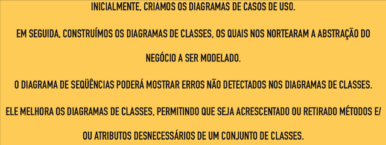

### 1.3. Notação

**Figura 2: Representação dos Símbolos do Diagrama de Sequencias**

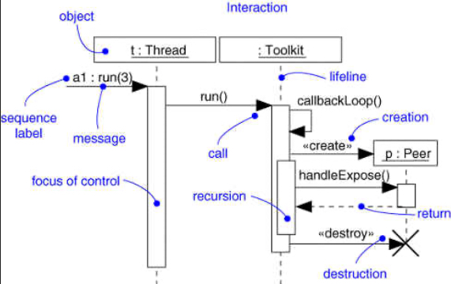

Fonte: Autoria desconhecida

### 1.4. Mensagens trocadas entre os objetos do Diagrama de Sequencias

- Chamada de Função ou Procedimento.
- Envio de Mensagem.
- Ocorrência de Evento.

### 1.4.1. Chamada de Função ou Procedimento

- Uma das interações mais freqüentes entre objetos é a **chamada de função**.
- Uma **chamada de função** significa que um objeto esta solicitando a execução de uma função (um método) de um outro objeto.
- Este conceito segue estritamente o processo de **chamada de função ou de procedimento** utilizado nas linguagens de programação.
- Obviamente, para que um objeto possa chamar um método de outro objeto é necessário que o método seja declarado como publico na classe respectiva.

### 1.4.2. Envio de Mensagem

- Objetos também podem **comunicar-se com outros objetos** através do envio explícito de uma mensagem.
- O **envio de uma mensagem**, ao contrário da chamada de função, não é uma interação direta entre dois objetos.
- Na verdade, **quando um objeto envia uma mensagem a outro objeto**, a mensagem é roteada ou encaminhada por algum mecanismo de entrega de mensagens.
- Normalmente, este serviço é prestado pelo sistema operacional através de mecanismos como **Message Queries (filas de mensagens) ou serviços de notificação**.

### 1.4.3. Ocorrência de Evento

- Existem também **outras formas de interação entre objetos através de eventos**. Esta é também a forma padrão de interação entre objetos e atores.
- Basicamente, **um evento é algum acontecimento externo ao software**, mas que é a ele notificado, pois lhe diz respeito.
- A notificação, ou seja, a indicação de que um determinado evento ocorreu é, na maioria dos casos, feita pelo sistema operacional.
- **Eventos** podem também ser gerados pelo software para o sistema operacional.
- Exemplos são as saídas para dispositivos (monitor, porta serial, disco) feitos através de serviços do sistema operacional.

### 1.5. Tipo de Mensagens

- A **notação gráfica para as trocas de mensagens** segmentos de reta com uma seta aberta em uma das extremidades. Esta é a **notação genérica para mensagens** que pode ser utilizada nas primeiras versões dos diagramas de seqüência.
- Em diagramas mais detalhados, entretanto, será utilizada outra notação de forma a indicar também o tipo das mensagens.
- Existem dois tipos de mensagens:
  - chamadas de mensagens de **síncronas**.
  - chamadas de mensagens de **assíncronas**.

### 1.5.1. Mensagens Síncronas

- Mensagens **síncronas são mensagens que implicam um sincronismo rígido entre os estados do objeto que envia a mensagem e os do objeto de destino da mensagem**.
- Um sincronismo entre objetos pode ser entendido, de uma forma geral, como uma dependência na evolução de estado de um objeto sobre o estado de um segundo objeto.
- De uma forma mais direta, pode-se dizer que uma mensagem **síncrona implica que o objeto que enviou a mensagem aguarde a conclusão do processamento da mensagem (entendida como um sinal de sincronismo) feito pelo objeto destino, para então prosseguir seu fluxo de execução**.
- O **exemplo mais comum de mensagem síncrona é a chamada de função**.
  - Em uma chamada de função o objeto que faz a chamada é empilhado e fica neste estado até a conclusão do processamento da função chamada. Trata-se, portanto, de um sincronismo rígido entre o objeto chamador e o objeto chamado. Alguns sistemas operacionais oferecem também mecanismos de troca de mensagens síncronas de forma que o objeto que envia a mensagem fique em estado de espera até a conclusão do tratamento da mensagem.
- A **notação UML para uma mensagem síncrona** é a de um segmento de reta com uma seta cheia em uma das extremidades.

### 1.5.1. Mensagens Assíncronas

- Mensagens **assíncronas são mensagens enviadas de um objeto a outro sem que haja uma dependência de estado entre os dois objetos**.
- O objeto de origem envia a mensagem e prossegue seu processamento independentemente do tratamento da mensagem feita no objeto destino.
- Os **mecanismos de envio de mensagens suportados pelos sistemas operacionais são o exemplo mais comum deste tipo de mensagem**.
- Além disso, de uma forma geral, **todas as comunicações entre atores e objetos representam trocas de mensagem assíncronas**.
- Considere, por exemplo, uma operação para apresentação de uma mensagem no monitor. Um objeto executa uma instrução print (ou print ou write) e o sistema despacha a mensagem para o ator (o monitor). O objeto prossegue seu processamento independentemente do desfecho na operação. Observe que os softwares não bloqueiam quando o monitor não apresenta alguma informação.
- A **notação UML para uma mensagem assíncrona** é a de um segmento de reta com uma meia seta em uma das extremidades.

### 1.6. Autodelegação de Mensagens

- Um **objeto pode enviar mensagens para outros objetos e pode também enviar mensagens para ele próprio**.
- *Uma mensagem enviada de um objeto para ele próprio chama-se uma **Autodelegação***.
- **Mensagens de Autodelegação podem ser síncronas ou assíncronas**.
- O caso mais comum de **mensagens assíncronas é o envio de uma mensagem de um objeto para ele mesmo através de mecanismos de envio de mensagens do sistema operacional**.
- O caso mais comum de **mensagens de Autodelegação síncronas é a chamada de função de um objeto pelo próprio objeto**.

### 1.7. Molduras do Diagrama de Sequencia

- Para apoiar as construções condicionais e de iteração (entre muitas outras coisas) a UML usa molduras.
- E sobre a linha da vida relacionada incluir ou representar a **GUARDA** (teste booleano) ou cláusula condicional.

| Operador da moldura | Significado |
| --- | --- |
| ALT | Fragmento alternativo para lógica condicional de exclusão mútua expresso em guardas. |
| LOOP | Fragmento de loop enquanto a guarda é verdadeira. Loop(n) para indicar o número de iterações. |
| OPT | Fragmento opcional executado se a guarda é verdadeira. |
| PAR | Fragmentos paralelos executados em paralelo. |
| REGIÃO | Região crítica dentro da qual apenas uma linha (thread) de execução pode ser executada. |

### 1.7.1. Exemplo do Diagrama de Sequencia com uso de Molduras

**Figura 3: Representação do Diagrama de Sequencia com uso de Molduras - Sistema de Leilão**

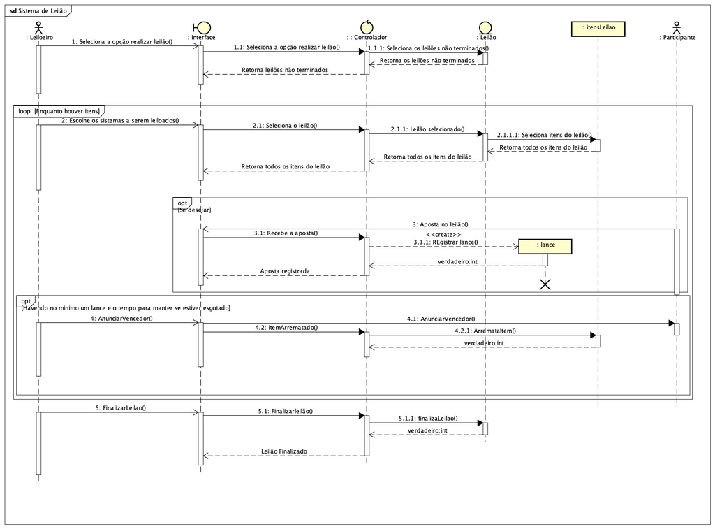

Fonte: Autoria própria

### Referências

- Esta aula foi elaborada a partir do conteúdo disponibilizado em cada um dos links indicados no próprio texto.
- GUEDES, G. T. A. UML 2 - **UMA ABORDAGEM PRÁTICA**. [S.L.]: NOVATEC, 2011.
- MEDEIROS, Ernani - **Desenvolvendo Software com UML 2.0 Definitivo** - Editora Pearson Makron Books.
- BOOCH, Grady; RUMBAUGH, James; JACOBSON, Ivar - **UML Guia do Usuário** - 2a. Edição - Editora Campus (Elsevier).
- BEZERRA, EDUARDO - **Princípios de Aálise e Projeto de Sistemas com UML** - EDITORA CAMPUS.
- [Marcoratti](http://www.macoratti.net/VB_UML2.HTM) - UML Conceitos Básicos II.

### Perguntas

- Esclareça suas eventuais dúvidas durante as aulas.
- Ou pelo *E-mail*: paulagiancoli@ifsp.edu.br.
- Ou acesse [Github Ana Giancoli](https://anagiancoli.github.io) e solicite atendimento para o componente curricular.
- Ou pelo *Fórum* do componente curricular.

*ADS - AOO - 3o. módulo*.  
Modelo e formato elaborado por profa. Ana Paula Müller Giancoli - BSD 2-Clause License. - Setembro.2020.